# Testing IHS

```r
library(tidyverse)
library(terra)
library(sf)
library(leaflet)
library(scico)
```

## Choose sample points

With the data produced in the last step, maps of average membership for each ECC can be produced.

```r
map_dir <- file.path('data_spatial', 'model_outputs')

cl_04 <- rast(file.path(map_dir, 'cluster_04_membership.tif'))
cl_05 <- rast(file.path(map_dir, 'cluster_05_membership.tif'))
cl_06 <- rast(file.path(map_dir, 'cluster_06_membership.tif'))
cl_07 <- rast(file.path(map_dir, 'cluster_07_membership.tif'))
cl_08 <- rast(file.path(map_dir, 'cluster_08_membership.tif'))

ecc_map <- rast(file.path(map_dir, 'ecc_map.tif'))

eccs <- read_csv(file.path('sample_plan', 'ECC_table.csv')) %>%
  dplyr::filter(is_unique == TRUE & rep_area > 20)

head(eccs)
```

```
#> # A tibble: 6 × 10
#>   fcm_04 fcm_05 fcm_06 fcm_07 fcm_08 ecc_name  rep_grade rep_area   uid is_uni…¹
#>    <dbl>  <dbl>  <dbl>  <dbl>  <dbl> <chr>         <dbl>    <dbl> <dbl> <lgl>
#> 1      2      2      2      2      8 2-2-2-2-8         5     1107     1 TRUE
#> 2      3      3      6      6      6 3-3-6-6-6         5      275     2 TRUE
#> 3      1      1      5      1      1 1-1-5-1-1         5      134     3 TRUE
#> 4      1      5      5      1      5 1-5-5-1-5         5      113     4 TRUE
#> 5      2      1      1      7      2 2-1-1-7-2         5       80     5 TRUE
#> 6      1      1      1      7      1 1-1-1-7-1         5       37     6 TRUE
#> # … with abbreviated variable name ¹is_unique
```

Lets map out potential sites for the first ECC as an example.

### 2-2-2-2-8

First, pull out the relevant cluster map from each set of outputs, and take the mean.

```r
clchain_mem <- rast(list(cl_04[[2]],
                         cl_05[[2]],
                         cl_06[[2]],
                         cl_07[[2]],
                         cl_08[[8]])
                     )
# calculate the average membership on each pixel
mean_mem_01 <- mean(clchain_mem)
```

Second, take the ECC map and mask it to the UID of this ECC, which in this case is `1`. Use the mask to remove any membership information from outside of the ECC’s area.

```r
mask_mem_01 <- ecc_map
mask_mem_01[mask_mem_01 != 1] <- NA # number from ecc_map$uid
mask_mem_01[mask_mem_01 == 1] <- 0

ecc_01 <- mean_mem_01 + mask_mem_01

if(!dir.exists(file.path('data_spatial', 'ecc_results'))) {
  dir.create(file.path('data_spatial', 'ecc_results'))
}

writeRaster(ecc_01,
            file.path('data_spatial', 'ecc_results', 'ecc_01.tif'),
            overwrite = TRUE,
            datatype = 'FLT4S',
            gdal = "COMPRESS=LZW")
```

[interactive chart not shown]

At this point, one could pick any non-NA cell in the above map to sample as being representative of this ECC. Ideally the site would be located where the average membership is as high as possible, allowing for efficient access. These surfaces are somewhat analogous to the Gower dissimilarity surfaces used by Brungard and Johanson (2015) for flexible cLHS sampling.

The location of the ‘best’ pixel on this surface could be chosen automatically, but there’s a danger of selecting pixels containing features that prevent sampling, or that are otherwise physically inaccessible.

A more careful approach could be to export a set of the *n* highest-membership pixels for each ECC, and check them manually for accessibility in a GIS before choosing.

Below, the top twenty pixels for the first cluster chain are selected for evaluation:

```r
best_vals_01 <- sort(terra::values(ecc_01), decreasing = TRUE)[seq(20)]
best_cells_01 <- which(terra::values(ecc_01) %in% best_vals_01)
bs_01 <- terra::xyFromCell(ecc_01, best_cells_01)
poss_pts_01 <- st_as_sf(data.frame(bs_01),
                        coords = c(1, 2),
                        crs = 2193) %>%
  mutate(VAL = terra::extract(ecc_01, best_cells_01)[[1]]) %>%
  arrange(desc(VAL)) %>%
  mutate(ID = seq(nrow(.)))

write_sf(poss_pts_01,
         file.path('data_spatial', 'ecc_results', 'ecc_01_poss_pts.gpkg'),
         delete_dsn = TRUE)
```

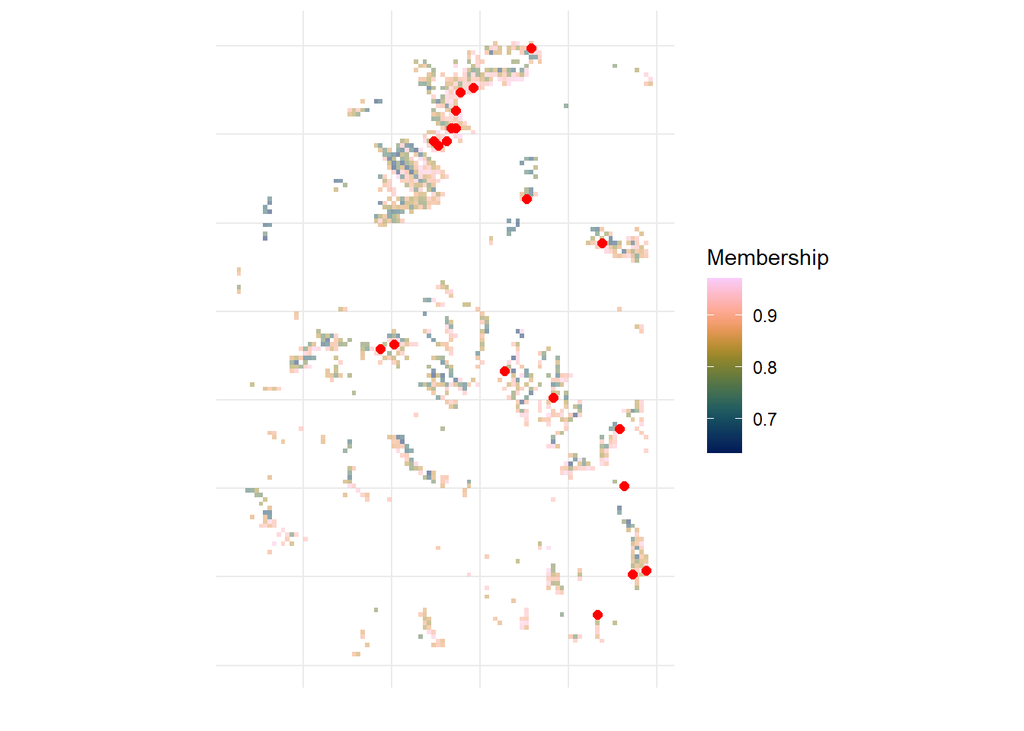

Some of these points are on isolated pixels. Depending on the inputs being clustered and what the clusters are expected to represent spatially, it may be prudent to first de-speckle the ECC map and target the highest membership value within a large, contiguous patch. However, a spatially aware clustering method should probably be used before attempting this.

Still, here’s how to de-speckle the ECC surface:

```r
# https://gis.stackexchange.com/questions/432539/delete-single-pixels-noise-from-raster
ecc_01_patch <- patches(ecc_01, directions = 8)
ecc_01_area <- zonal(cellSize(ecc_01_patch, unit="m"),
                     ecc_01_patch,
                     sum,
                     as.raster = TRUE)

# remove patches < 0.2 ha
ecc_01_clean <- terra::ifel(ecc_01_area < 2000, NA, ecc_01)
```

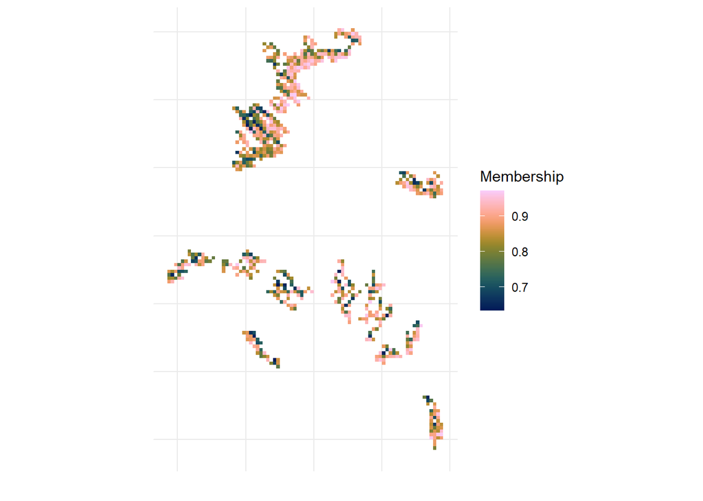

Below, the point-choosing exercise is repeated for the other 8 ECCs. Note that the results are visibly substandard, but this is the result of just repeating the covariates used in Yang et al. (2013). As the precursor paper Zhu et al. (2010) notes, these are not expected to be universally applicable choices in all landscapes.

```r
mean_mem_02 <-
  mean(rast(list(cl_04[[3]],
                 cl_05[[3]],
                 cl_06[[3]],
                 cl_07[[6]],
                 cl_08[[6]])))

mask_mem_02 <- ecc_map
mask_mem_02[mask_mem_02 != 2] <- NA
mask_mem_02[mask_mem_02 == 2] <- 0

ecc_02 <- mean_mem_02 + mask_mem_02

# note that ECCs with ncell < 20 have been dropped
best_vals_02 <- sort(terra::values(ecc_02), decreasing = TRUE)[seq(20)]
best_cells_02 <- which(terra::values(ecc_02) %in% best_vals_02)
bs_02 <- terra::xyFromCell(ecc_02, best_cells_02)
poss_pts_02 <- st_as_sf(data.frame(bs_02),
                        coords = c(1, 2),
                        crs = 2193) %>%
  mutate(VAL = terra::extract(ecc_02, best_cells_02)[[1]]) %>%
  arrange(desc(VAL)) %>%
  mutate(ID = seq(nrow(.)))
```

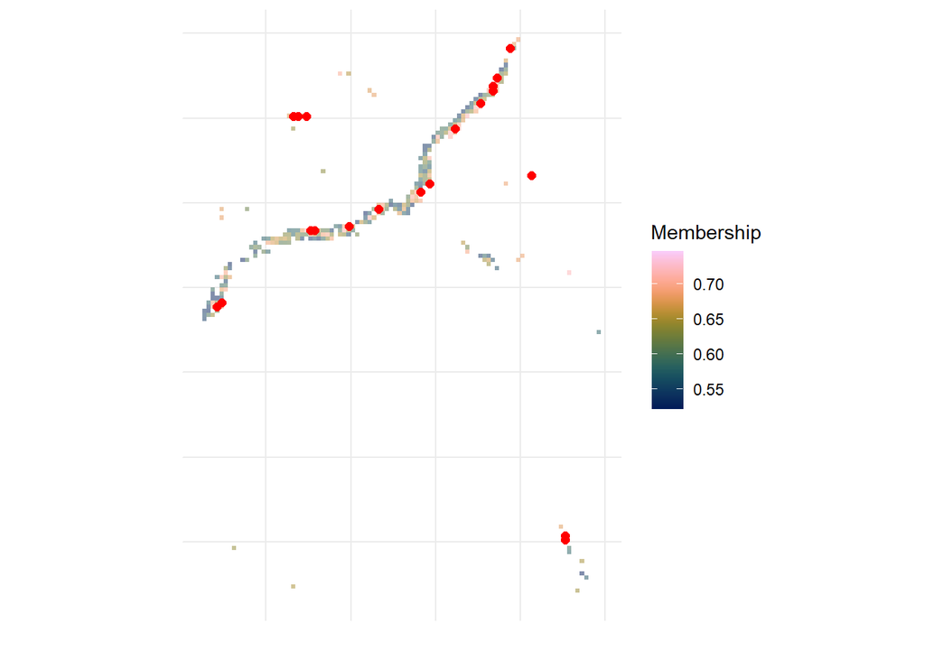

**1-1-5-1-1**

```r
mean_mem_03 <-
  mean(rast(list(cl_04[[1]],
                 cl_05[[1]],
                 cl_06[[5]],
                 cl_07[[1]],
                 cl_08[[1]])))

mask_mem_03 <- ecc_map
mask_mem_03[mask_mem_03 != 3] <- NA
mask_mem_03[mask_mem_03 == 3] <- 0

ecc_03 <- mean_mem_03 + mask_mem_03

# note that ECCs with ncell < 20 have been dropped
best_vals_03 <- sort(terra::values(ecc_03), decreasing = TRUE)[seq(20)]
best_cells_03 <- which(terra::values(ecc_03) %in% best_vals_03)
bs_03 <- terra::xyFromCell(ecc_03, best_cells_03)
poss_pts_03 <- st_as_sf(data.frame(bs_03),
                        coords = c(1, 2),
                        crs = 2193) %>%
  mutate(VAL = terra::extract(ecc_03, best_cells_03)[[1]]) %>%
  arrange(desc(VAL)) %>%
  mutate(ID = seq(nrow(.)))
```

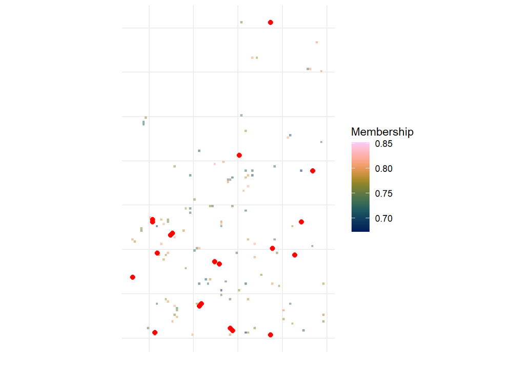

**1-5-5-1-5**

```r
mean_mem_04 <-
  mean(rast(list(cl_04[[1]],
                 cl_05[[5]],
                 cl_06[[5]],
                 cl_07[[1]],
                 cl_08[[5]])))

mask_mem_04 <- ecc_map
mask_mem_04[mask_mem_04 != 4] <- NA
mask_mem_04[mask_mem_04 == 4] <- 0

ecc_04 <- mean_mem_04 + mask_mem_04

# note that ECCs with ncell < 20 have been dropped
best_vals_04 <- sort(terra::values(ecc_04), decreasing = TRUE)[seq(20)]
best_cells_04 <- which(terra::values(ecc_04) %in% best_vals_04)
bs_04 <- terra::xyFromCell(ecc_04, best_cells_04)
poss_pts_04 <- st_as_sf(data.frame(bs_04),
                        coords = c(1, 2),
                        crs = 2193) %>%
  mutate(VAL = terra::extract(ecc_04, best_cells_04)[[1]]) %>%
  arrange(desc(VAL)) %>%
  mutate(ID = seq(nrow(.)))
```

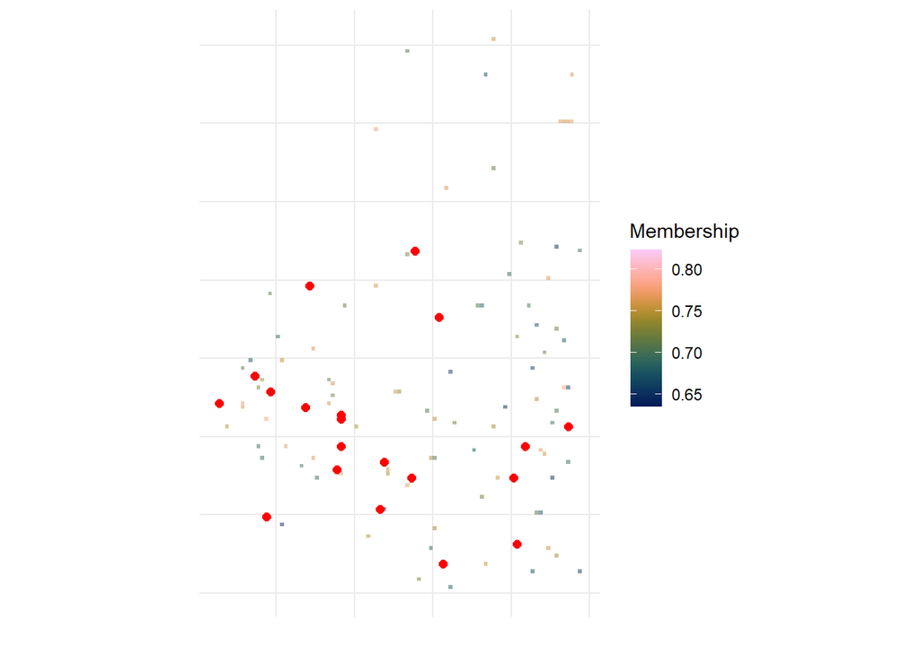

**2-1-1-7-2**

```r
mean_mem_05 <-
  mean(rast(list(cl_04[[2]],
                 cl_05[[1]],
                 cl_06[[1]],
                 cl_07[[7]],
                 cl_08[[2]])))

mask_mem_05 <- ecc_map
mask_mem_05[mask_mem_05 != 5] <- NA
mask_mem_05[mask_mem_05 == 5] <- 0

ecc_05 <- mean_mem_05 + mask_mem_05

# note that ECCs with ncell < 20 have been dropped
best_vals_05 <- sort(terra::values(ecc_05), decreasing = TRUE)[seq(20)]
best_cells_05 <- which(terra::values(ecc_05) %in% best_vals_05)
bs_05 <- terra::xyFromCell(ecc_05, best_cells_05)
poss_pts_05 <- st_as_sf(data.frame(bs_05),
                        coords = c(1, 2),
                        crs = 2193) %>%
  mutate(VAL = terra::extract(ecc_05, best_cells_05)[[1]]) %>%
  arrange(desc(VAL)) %>%
  mutate(ID = seq(nrow(.)))
```

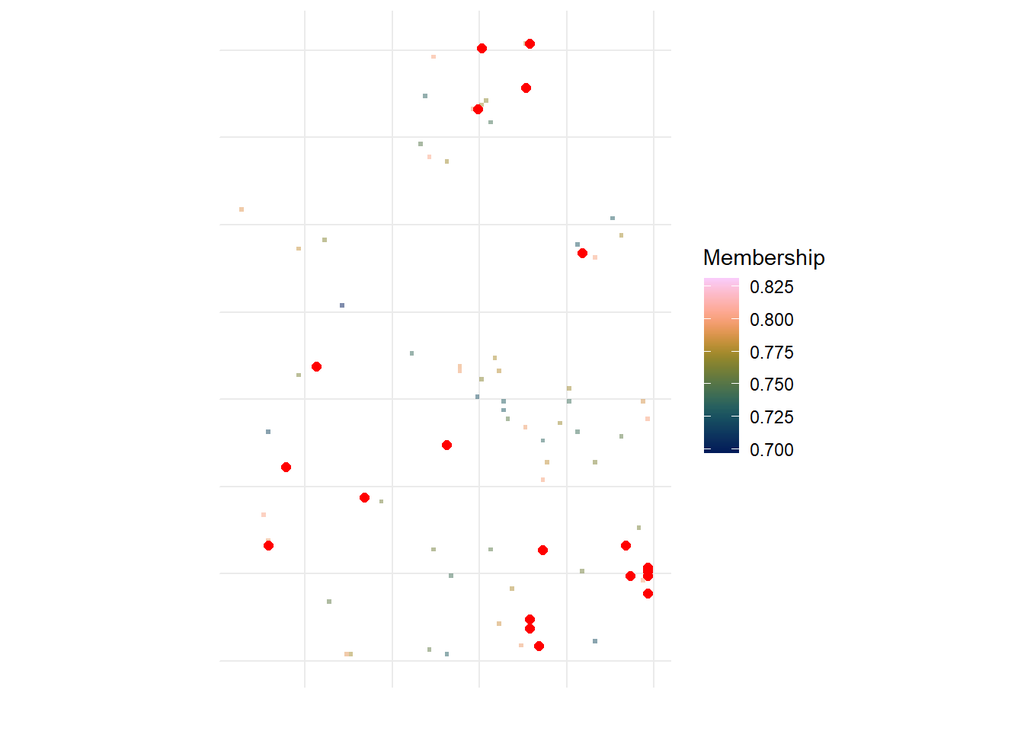

**1-1-1-7-1**

```r
mean_mem_06 <-
  mean(rast(list(cl_04[[1]],
                 cl_05[[1]],
                 cl_06[[1]],
                 cl_07[[7]],
                 cl_08[[1]])))

mask_mem_06 <- ecc_map
mask_mem_06[mask_mem_06 != 6] <- NA
mask_mem_06[mask_mem_06 == 6] <- 0

ecc_06 <- mean_mem_06 + mask_mem_06

# note that ECCs with ncell < 20 have been dropped
best_vals_06 <- sort(terra::values(ecc_06), decreasing = TRUE)[seq(20)]
best_cells_06 <- which(terra::values(ecc_06) %in% best_vals_06)
bs_06 <- terra::xyFromCell(ecc_06, best_cells_06)
poss_pts_06 <- st_as_sf(data.frame(bs_06),
                        coords = c(1, 2),
                        crs = 2193) %>%
  mutate(VAL = terra::extract(ecc_06, best_cells_06)[[1]]) %>%
  arrange(desc(VAL)) %>%
  mutate(ID = seq(nrow(.)))
```

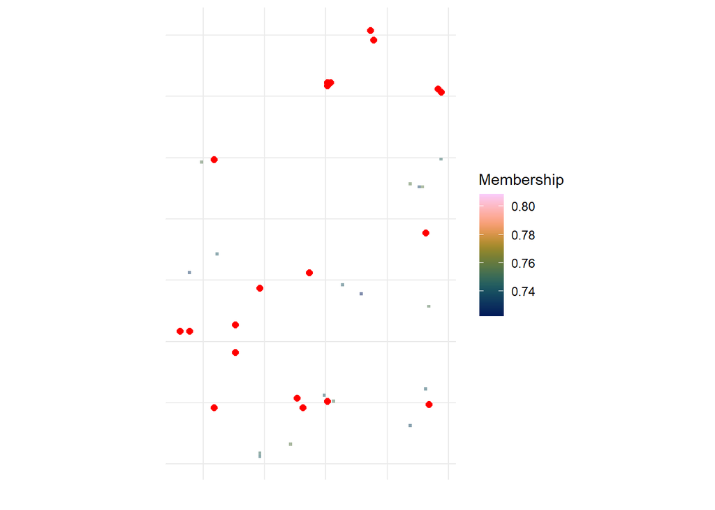

**2-2-0-7-2**

```r
mean_mem_07 <-
  mean(rast(list(cl_04[[2]],
                 cl_05[[2]],
                #cl_06[[0]], # just skip  at lower rgs
                 cl_07[[7]],
                 cl_08[[2]])))

mask_mem_07 <- ecc_map
mask_mem_07[mask_mem_07 != 16] <- NA
mask_mem_07[mask_mem_07 == 16] <- 0

ecc_07 <- mean_mem_07 + mask_mem_07

# note that ECCs with ncell < 20 have been dropped
best_vals_07 <- sort(terra::values(ecc_07), decreasing = TRUE)[seq(20)]
best_cells_07 <- which(terra::values(ecc_07) %in% best_vals_07)
bs_07 <- terra::xyFromCell(ecc_07, best_cells_07)
poss_pts_07 <- st_as_sf(data.frame(bs_07),
                        coords = c(1, 2),
                        crs = 2193) %>%
  mutate(VAL = terra::extract(ecc_07, best_cells_07)[[1]]) %>%
  arrange(desc(VAL)) %>%
  mutate(ID = seq(nrow(.)))
```

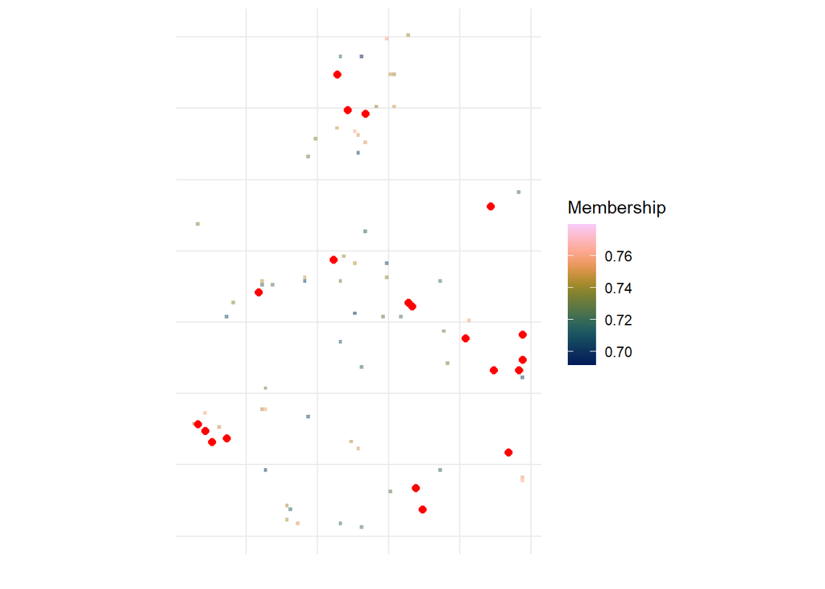

**4-5-3-5-0**

```r
mean_mem_08 <-
  mean(rast(list(cl_04[[4]],
                 cl_05[[5]],
                 cl_06[[3]],
                 cl_07[[5]] #,
                 #cl_08[[0]]
                 )))

mask_mem_08 <- ecc_map
mask_mem_08[mask_mem_08 != 21] <- NA
mask_mem_08[mask_mem_08 == 21] <- 0

ecc_08 <- mean_mem_08 + mask_mem_08

# note that ECCs with ncell < 20 have been dropped
best_vals_08 <- sort(terra::values(ecc_08), decreasing = TRUE)[seq(20)]
best_cells_08 <- which(terra::values(ecc_08) %in% best_vals_08)
bs_08 <- terra::xyFromCell(ecc_08, best_cells_08)
poss_pts_08 <- st_as_sf(data.frame(bs_08),
                        coords = c(1, 2),
                        crs = 2193) %>%
  mutate(VAL = terra::extract(ecc_08, best_cells_08)[[1]]) %>%
  arrange(desc(VAL)) %>%
  mutate(ID = seq(nrow(.)))
```

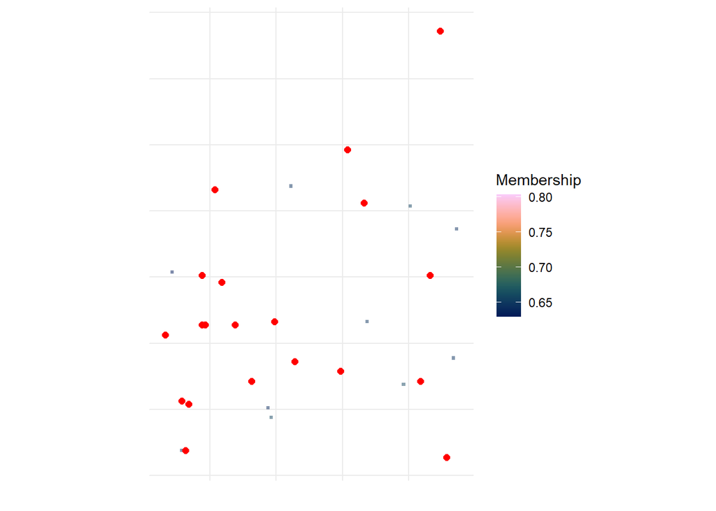

**3-3-0-3-3**

```r
mean_mem_09 <-
  mean(rast(list(cl_04[[3]],
                 cl_05[[3]],
                #cl_06[[0]], # just skip  at lower rgs
                 cl_07[[3]],
                 cl_08[[3]])))

mask_mem_09 <- ecc_map
mask_mem_09[mask_mem_09 != 22] <- NA
mask_mem_09[mask_mem_09 == 22] <- 0

ecc_09 <- mean_mem_09 + mask_mem_09

# note that ECCs with ncell < 20 have been dropped
best_vals_09 <- sort(terra::values(ecc_09), decreasing = TRUE)[seq(20)]
best_cells_09 <- which(terra::values(ecc_09) %in% best_vals_09)
bs_09 <- terra::xyFromCell(ecc_09, best_cells_09)
poss_pts_09 <- st_as_sf(data.frame(bs_09),
                        coords = c(1, 2),
                        crs = 2193) %>%
  mutate(VAL = terra::extract(ecc_09, best_cells_09)[[1]]) %>%
  arrange(desc(VAL)) %>%
  mutate(ID = seq(nrow(.)))
```

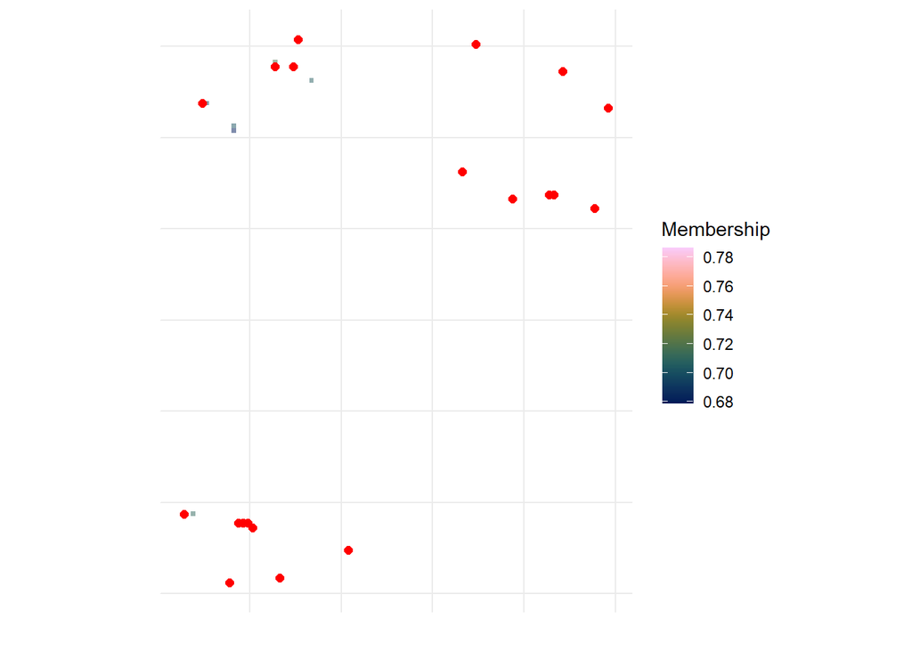

## References

Brungard, Colby, and Jamin Johanson. 2015. “The Gate’s Locked! I Can’t Get to the Exact Sampling Spot … Can i Sample Nearby?” In, edited by Jing Liu, 8–10. IUSS. https://www.pedometrics.org/Pedometron/Pedometron37.pdf.

Yang, L., A. X. Zhu, F. Qi, C. Z. Qin, B. Li, and T. Pei. 2013. “An Integrative Hierarchical Stepwise Sampling Strategy for Spatial Sampling and Its Application in Digital Soil Mapping.” *International Journal of Geographical Information Science* 27 (1): 1–23. https://doi.org/10.1080/13658816.2012.658053.

Zhu, A. Xing, Feng Qi, Amanda Moore, and James E. Burt. 2010. “Prediction of Soil Properties Using Fuzzy Membership Values.” *Geoderma* 158 (3): 199–206. https://doi.org/10.1016/j.geoderma.2010.05.001.